# Question 1

## Trading Strategy

```python
df1 = df.copy()
df1['Signal'] = tun_model.predict(X)
```

```python
df1
```

| Date | OPEN | HIGH | LOW | CLOSE | ADJ CLOSE | VOLUME | matching | OC | HL | LRET | ... | LRET7 | RET7 | MA7 | EWMA_7 | OC7 | HL7 | MOM7 | PRET7 | LABEL | Signal |
| --- | --- | --- | --- | --- | --- | --- | --- | --- | --- | --- | --- | --- | --- | --- | --- | --- | --- | --- | --- | --- | --- |
| 2013-06-07 | 1,411.5000 | 1,416.1000 | 1,377.9000 | 1,383.0000 | 1,383.0000 | 1163 | True | -0.0202 | 0.0277 | -0.0234 | ... | -0.0060 | -0.0060 | 1,401.4286 | 1,397.3565 | -0.0005 | 0.0209 | -8.3000 | 0.0206 | 1,386.2000 | 1 |
| 2013-06-10 | 1,378.8000 | 1,386.9000 | 1,375.6000 | 1,386.2000 | 1,386.2000 | 367 | True | 0.0054 | 0.0082 | 0.0023 | ... | -0.0181 | -0.0179 | 1,397.8143 | 1,394.5674 | -0.0017 | 0.0190 | -25.3000 | 0.0028 | 1,377.0000 | 1 |
| 2013-06-11 | 1,384.2000 | 1,384.4000 | 1,366.0000 | 1,377.0000 | 1,377.0000 | 482 | True | -0.0052 | 0.0135 | -0.0067 | ... | -0.0113 | -0.0112 | 1,395.5857 | 1,390.1755 | -0.0004 | 0.0171 | -15.6000 | -0.0037 | 1,391.8000 | 1 |
| 2013-06-12 | 1,375.0000 | 1,393.5000 | 1,373.7000 | 1,391.8000 | 1,391.8000 | 514 | True | 0.0122 | 0.0144 | 0.0107 | ... | -0.0142 | -0.0141 | 1,392.7429 | 1,390.5817 | -0.0010 | 0.0163 | -19.8999 | -0.0247 | 1,377.6000 | 1 |
| 2013-06-13 | 1,386.8000 | 1,390.9000 | 1,373.4000 | 1,377.6000 | 1,377.6000 | 458 | True | -0.0066 | 0.0127 | -0.0103 | ... | -0.0141 | -0.0140 | 1,389.9571 | 1,387.3362 | -0.0005 | 0.0156 | -19.5000 | -0.0006 | 1,387.3000 | 1 |
| ... | ... | ... | ... | ... | ... | ... | ... | ... | ... | ... | ... | ... | ... | ... | ... | ... | ... | ... | ... | ... | ... |
| 2023-05-19 | 1,960.0000 | 1,978.7000 | 1,960.0000 | 1,978.7000 | 1,978.7000 | 106 | True | 0.0095 | 0.0095 | 0.0113 | ... | -0.0258 | -0.0255 | 1,993.0714 | 1,988.8148 | 0.0001 | 0.0036 | -51.8000 | -0.0351 | 1,974.8000 | 1 |
| 2023-05-22 | 1,980.5000 | 1,980.5000 | 1,974.8000 | 1,974.8000 | 1,974.8000 | 8 | True | -0.0029 | 0.0029 | -0.0020 | ... | -0.0200 | -0.0198 | 1,987.3714 | 1,985.3111 | 0.0010 | 0.0023 | -39.8999 | -0.0286 | 1,972.4000 | 1 |
| 2023-05-23 | 1,972.4000 | 1,972.4000 | 1,972.4000 | 1,972.4000 | 1,972.4000 | 1 | True | 0.0000 | 0.0000 | -0.0012 | ... | -0.0211 | -0.0209 | 1,981.3571 | 1,982.0833 | 0.0010 | 0.0023 | -42.1000 | -0.0278 | 1,962.8000 | 1 |
| 2023-05-24 | 1,975.4000 | 1,975.4000 | 1,962.8000 | 1,962.8000 | 1,962.8000 | 189 | True | -0.0064 | 0.0064 | -0.0049 | ... | -0.0277 | -0.0274 | 1,973.4714 | 1,977.2625 | -0.0002 | 0.0029 | -55.2000 | -0.0212 | 1,943.1000 | 1 |
| 2023-05-25 | 1,943.1000 | 1,943.1000 | 1,943.1000 | 1,943.1000 | 1,943.1000 | 1 | True | 0.0000 | 0.0000 | -0.0101 | ... | -0.0230 | -0.0228 | 1,967.0000 | 1,968.7219 | -0.0002 | 0.0029 | -45.3000 | -0.0260 | 1,944.1000 | 1 |

2509 rows × 23 columns

```python
# Daily Returns
df1['RETURNS'] = np.log(df1['ADJ CLOSE']).diff().fillna(0)

# Strategy Returns
df1['STRATEGY'] = df1['RETURNS'] * df1['Signal'].shift(1).fillna(0)

# Localize index for pyfolio
df1.index = df1.index.tz_localize('utc')

df1.tail()
```

| Date | OPEN | HIGH | LOW | CLOSE | ADJ CLOSE | VOLUME | matching | OC | HL | LRET | ... | MA7 | EWMA_7 | OC7 | HL7 | MOM7 | PRET7 | LABEL | Signal | RETURNS | STRATEGY |
| --- | --- | --- | --- | --- | --- | --- | --- | --- | --- | --- | --- | --- | --- | --- | --- | --- | --- | --- | --- | --- | --- |
| 2023-05-19 00:00:00+00:00 | 1,960.0000 | 1,978.7000 | 1,960.0000 | 1,978.7000 | 1,978.7000 | 106 | True | 0.0095 | 0.0095 | 0.0113 | ... | 1,993.0714 | 1,988.8148 | 0.0001 | 0.0036 | -51.8000 | -0.0351 | 1,974.8000 | 1 | 0.0113 | 0.0113 |
| 2023-05-22 00:00:00+00:00 | 1,980.5000 | 1,980.5000 | 1,974.8000 | 1,974.8000 | 1,974.8000 | 8 | True | -0.0029 | 0.0029 | -0.0020 | ... | 1,987.3714 | 1,985.3111 | 0.0010 | 0.0023 | -39.8999 | -0.0286 | 1,972.4000 | 1 | -0.0020 | -0.0020 |
| 2023-05-23 00:00:00+00:00 | 1,972.4000 | 1,972.4000 | 1,972.4000 | 1,972.4000 | 1,972.4000 | 1 | True | 0.0000 | 0.0000 | -0.0012 | ... | 1,981.3571 | 1,982.0833 | 0.0010 | 0.0023 | -42.1000 | -0.0278 | 1,962.8000 | 1 | -0.0012 | -0.0012 |
| 2023-05-24 00:00:00+00:00 | 1,975.4000 | 1,975.4000 | 1,962.8000 | 1,962.8000 | 1,962.8000 | 189 | True | -0.0064 | 0.0064 | -0.0049 | ... | 1,973.4714 | 1,977.2625 | -0.0002 | 0.0029 | -55.2000 | -0.0212 | 1,943.1000 | 1 | -0.0049 | -0.0049 |
| 2023-05-25 00:00:00+00:00 | 1,943.1000 | 1,943.1000 | 1,943.1000 | 1,943.1000 | 1,943.1000 | 1 | True | 0.0000 | 0.0000 | -0.0101 | ... | 1,967.0000 | 1,968.7219 | -0.0002 | 0.0029 | -45.3000 | -0.0260 | 1,944.1000 | 1 | -0.0101 | -0.0101 |

5 rows × 25 columns

| Start date End date Total months | 2013-06-07 2023-05-25 119 Backtest | 2013-06-07 2023-05-25 119 |
| --- | --- | --- |
| Annual return | -0.2% |  |
| Cumulative returns | -2.3% |  |
| Annual volatility | 11.6% |  |
| Sharpe ratio | 0.04 |  |
| Calmar ratio | -0.01 |  |
| Stability | 0.19 |  |
| Max drawdown | -28.3% |  |
| Omega ratio | 1.01 |  |
| Sortino ratio | 0.05 |  |
| Skew | -0.50 |  |
| Kurtosis | 12.23 |  |
| Tail ratio | 0.95 |  |
| Daily value at risk | -1.5% |  |

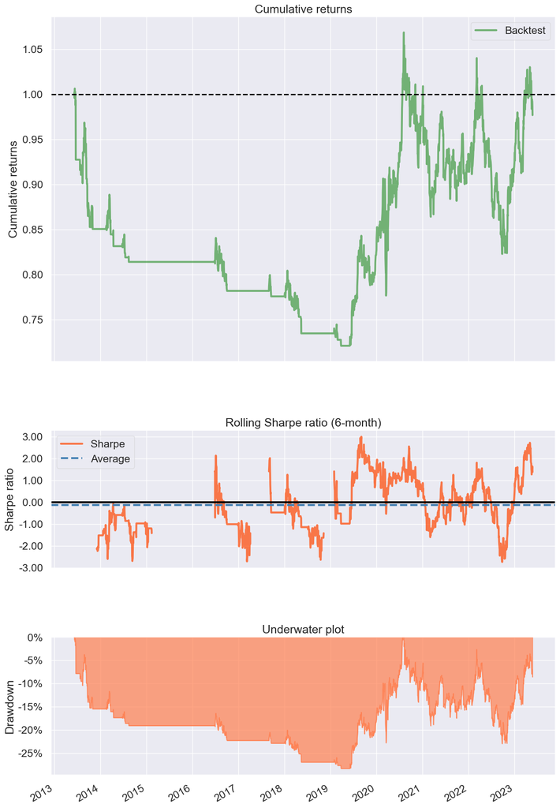

```python
pf.create_simple_tear_sheet(df1['STRATEGY'])
```

# Conclusion

However, this does contribute to the hypothesis that gold is a safe haven & should be bought and held for long term returns. Gold has also been used as an inflation in the more recent years hence it is trading at such a significant premium to the previous 8 years.

Future improvements would involve switching the commodities in my original input and see if the price features I have identified translate across to different commodity markets in the model. This would be a useful exercise to perform to see if the momentum carries and the model can predict more down days.